# GDP-mannose-dependent…

Fold-switch pair **4n9wA_4nc9C** — **4n9wA** vs **4nc9C**

Mycolicibacterium smegmatis MC2 155

## Figure 1: Phylogenetic tree with per-cluster fold-preference heatmap.

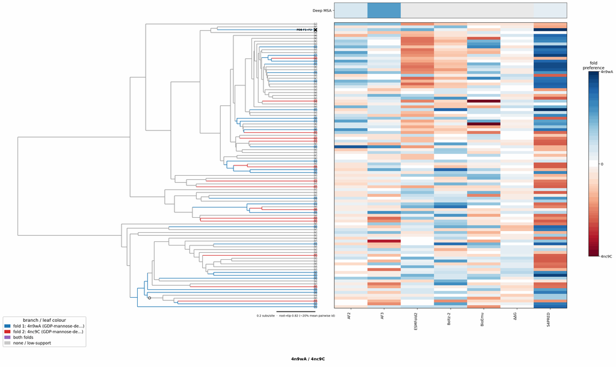

## Figure 2: Aligned overlay (both folds superposed)

The single fold-switching chain of each fold superposed by TM-align; waters hidden, any ligand shown as green sticks. Grey = structurally conserved core, colour = divergent (fold-switching) region.

4n9wA (GDP-mannose-dependent…)4nc9C (GDP-mannose-dependent…)Ligand GDP (bound to 4n9wA)

TM-score: 0.829 · Trigger class: ligand

Aligned overlay

## Figure 3: The two folds, side by side

Each fold is coloured by per-residue Cα deviation between the two superposed structures: grey ≈ conserved core, full colour = structurally divergent (fold-switching) region.

4n9wA (GDP-mannose-dependent…)

4nc9C (GDP-mannose-dependent…)

0 Å5≥10 Å

4n9wA (GDP-mannose-dependent…)

4nc9C (GDP-mannose-dependent…)

## Figure 4: Best-cluster predicted contact maps over the two true folds.

Predicted contact maps (MSA-Transformer) for the clusters best matching each fold, over the true contacts of fold 1 (upper triangle) and fold 2 (lower). Divergent contacts between clusters are the contact-level signature of fold-switching.

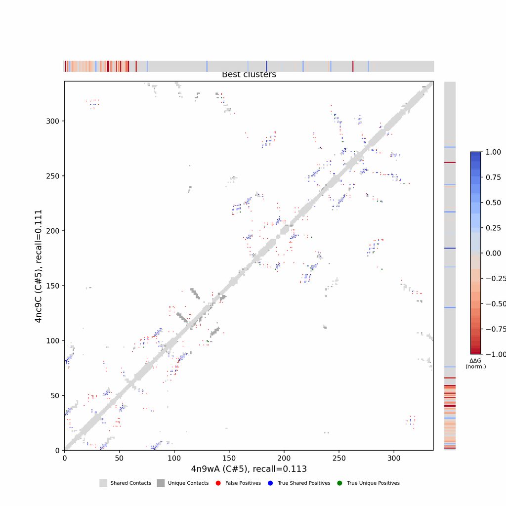

## Figure 5: Per-residue ΔΔG fold-preference contribution

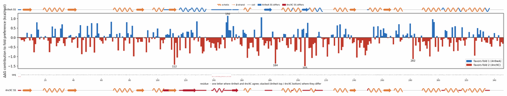

**More figures**

## Figure 6: Deep-MSA contact map panel / Best clusters contact map panel

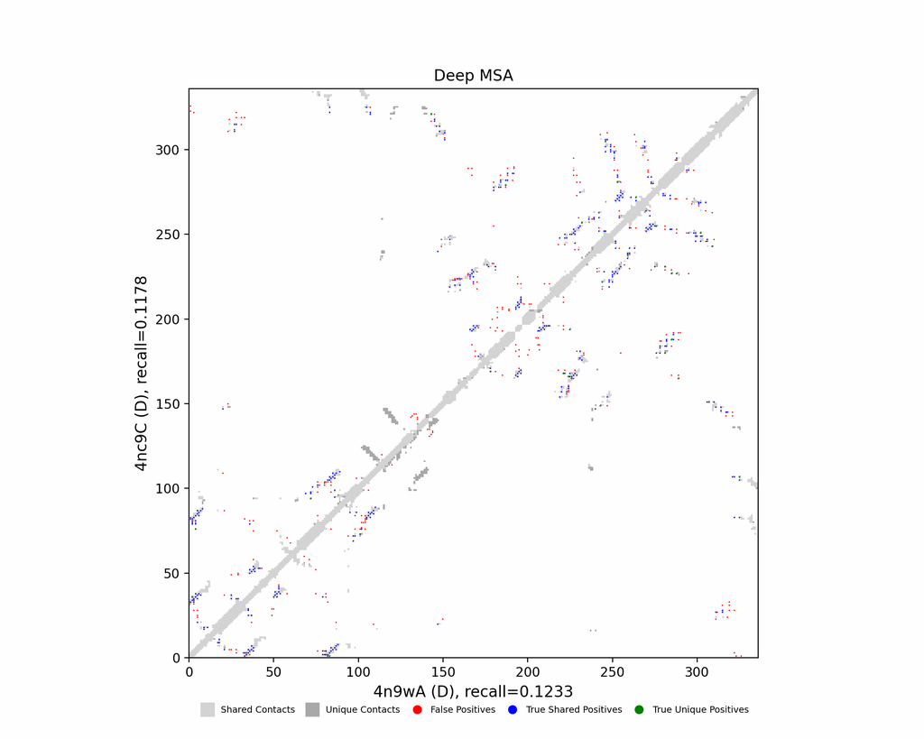

Deep-MSA contact map panel

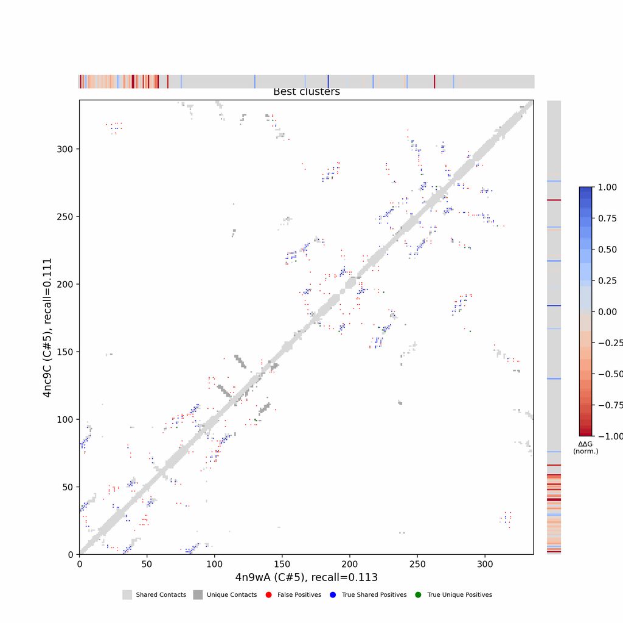

Best clusters contact map panel

## Figure 7: All clusters contact-map mosaic (small multiples).

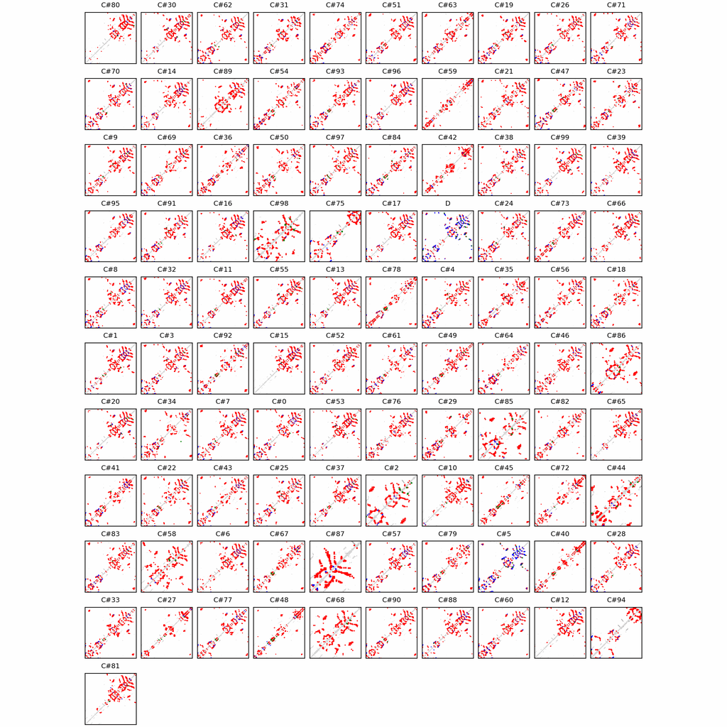

## Figure 8: Phylo null: tree with shuffled cluster fold labels.

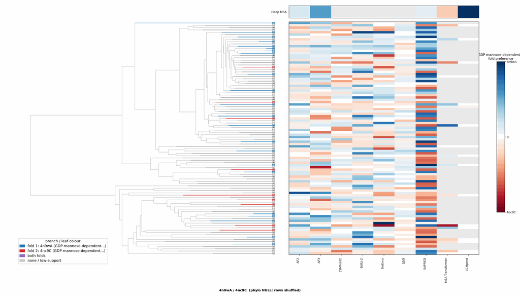

## Cluster metrics table

Per-cluster metrics underlying the figures above.

| cluster | n | neff | AF2_TM1 | AF2_TM2 | AF3_TM1 | AF3_TM2 | RE-MSAT-COM | RE-MSAT1 | RE-MSAT2 | ESM_SEQIDS | ESM_TM1 | ESM_TM2 | ΔΔG_Bias | ΔΔG_Bias_std | ΔΔG_frac_F1 | Boltz2_pref | S4PRED_pref | CCMpred_pref | BioEmu_pref |
| --- | --- | --- | --- | --- | --- | --- | --- | --- | --- | --- | --- | --- | --- | --- | --- | --- | --- | --- | --- |
| Deep | - | - | 0.9 | 0.87 | 0.91 | 0.85 | 0.47 | 0.46 | 0.42 | - | - | - | - | - | - | - | 0.01 | 0.01 | - |
| 000 | 816.0 | 539.0 | 0.51 | 0.47 | 0.82 | 0.73 | 0.07 | 0.06 | 0.07 | 001; 001; 003; 003; 002; 002; 005; 005; 004; 004 | 0.83 ± 0.02 | 0.76 ± 0.03 | -40.31 | 15.64 | 0.0 | 0.0 | -0.04 | -0.0 | 0.02 |
| 001 | 546.0 | 436.0 | 0.48 | 0.46 | 0.48 | 0.45 | 0.04 | 0.04 | 0.03 | 001; 005; 005; 001; 008; 009; 003; 003; 008; 009 | 0.80 ± 0.00 | 0.75 ± 0.02 | -34.65 | 11.45 | 0.0 | 0.01 | -0.05 | -0.0 | 0.02 |
| 002 | 526.0 | 342.0 | 0.86 | 0.8 | 0.86 | 0.85 | 0.04 | 0.06 | 0.05 | 001; 004; 004; 001; 003; 003; 005; 008; 002; 002 | 0.82 ± 0.01 | 0.76 ± 0.02 | -32.24 | 11.11 | 0.0 | 0.0 | 0.03 | 0.0 | 0.01 |
| 003 | 485.0 | 282.0 | 0.39 | 0.38 | 0.86 | 0.79 | 0.07 | 0.06 | 0.06 | 005; 005; 002; 002; 003; 004; 004; 003; 001; 001 | 0.82 ± 0.01 | 0.75 ± 0.01 | -38.38 | 13.23 | 0.0 | 0.08 | -0.05 | 0.0 | 0.01 |
| 004 | 416.0 | 211.0 | 0.49 | 0.47 | 0.8 | 0.77 | 0.04 | 0.04 | 0.05 | 002; 002; 005; 005; 001; 001; 007; 008; 007; 008 | 0.82 ± 0.02 | 0.76 ± 0.02 | -30.27 | 12.06 | 0.0 | 0.09 | -0.04 | 0.0 | 0.01 |
| 005 | 412.0 | 154.0 | 0.5 | 0.46 | 0.92 | 0.84 | 0.41 | 0.39 | 0.36 | 002; 003; 003; 002; 008; 008; 001; 005; 001; 005 | 0.82 ± 0.01 | 0.75 ± 0.01 | -32.24 | 16.37 | 0.1 | 0.03 | 0.05 | 0.0 | 0.0 |
| 006 | 364.0 | 338.0 | 0.84 | 0.8 | 0.87 | 0.82 | 0.04 | 0.04 | 0.03 | 009; 009; 001; 005; 001; 005; 008; 002; 002; 008 | 0.82 ± 0.01 | 0.76 ± 0.01 | -42.89 | 12.54 | 0.0 | 0.01 | -0.04 | 0.0 | 0.01 |
| 007 | 315.0 | 246.0 | 0.52 | 0.49 | 0.52 | 0.49 | 0.07 | 0.06 | 0.06 | 001; 001; 004; 004; 002; 005; 009; 005; 009; 002 | 0.80 ± 0.02 | 0.74 ± 0.02 | -36.86 | 10.47 | 0.0 | 0.02 | -0.03 | 0.0 | 0.02 |
| 008 | 313.0 | 258.0 | 0.24 | 0.24 | 0.76 | 0.7 | 0.09 | 0.07 | 0.08 | 001; 001; 002; 002; 008; 008; 007; 007; 003; 003 | 0.78 ± 0.12 | 0.72 ± 0.11 | -34.95 | 13.62 | 0.0 | -0.0 | -0.05 | 0.0 | 0.01 |
| 009 | 309.0 | 201.0 | 0.46 | 0.47 | 0.77 | 0.73 | 0.03 | 0.03 | 0.03 | 001; 001; 009; 009; 003; 003; 002; 002; 004; 004 | 0.83 ± 0.05 | 0.77 ± 0.04 | -31.51 | 11.38 | 0.0 | -0.0 | -0.02 | 0.0 | 0.01 |
| 010 | 291.0 | 261.0 | 0.86 | 0.78 | 0.87 | 0.84 | 0.01 | 0.01 | 0.01 | 002; 003; 005; 005; 003; 002; 001; 001; 007; 004 | 0.81 ± 0.01 | 0.75 ± 0.01 | -38.54 | 13.35 | 0.0 | -0.02 | 0.04 | 0.0 | 0.02 |
| 011 | 282.0 | 222.0 | 0.87 | 0.76 | 0.88 | 0.84 | 0.05 | 0.04 | 0.04 | 001; 002; 002; 001; 005; 007; 008; 005; 007; 008 | 0.81 ± 0.00 | 0.75 ± 0.02 | -38.28 | 15.54 | 0.0 | 0.01 | 0.02 | 0.0 | 0.03 |
| 012 | 252.0 | 229.0 | 0.87 | 0.77 | 0.89 | 0.84 | 0.03 | 0.03 | 0.02 | 001; 001; 002; 002; 004; 006; 006; 004; 007; 007 | 0.83 ± 0.02 | 0.76 ± 0.01 | -35.26 | 14.25 | 0.0 | -0.0 | 0.04 | 0.0 | -0.0 |
| 013 | 251.0 | 212.0 | 0.87 | 0.78 | 0.92 | 0.83 | 0.06 | 0.05 | 0.05 | 003; 003; 002; 002; 001; 009; 009; 006; 001; 006 | 0.83 ± 0.01 | 0.76 ± 0.01 | -40.68 | 14.31 | 0.0 | -0.0 | -0.04 | 0.0 | 0.01 |
| 014 | 247.0 | 204.0 | 0.78 | 0.71 | 0.88 | 0.83 | 0.05 | 0.04 | 0.04 | 002; 002; 003; 003; 001; 001; 005; 004; 004; 005 | 0.78 ± 0.03 | 0.71 ± 0.01 | -32.98 | 11.62 | 0.0 | -0.0 | 0.04 | 0.0 | 0.0 |
| 015 | 240.0 | 213.0 | 0.84 | 0.8 | 0.88 | 0.84 | 0.02 | 0.03 | 0.02 | 001; 001; 010; 010; 003; 003; 009; 009; 002; 002 | 0.83 ± 0.03 | 0.76 ± 0.02 | -32.17 | 13.54 | 0.0 | 0.0 | 0.03 | 0.0 | 0.0 |
| 016 | 237.0 | 213.0 | 0.85 | 0.74 | 0.88 | 0.82 | 0.05 | 0.05 | 0.04 | 004; 004; 001; 001; 003; 003; 006; 006; 002; 002 | 0.81 ± 0.02 | 0.74 ± 0.02 | -37.66 | 14.61 | 0.0 | -0.0 | 0.04 | 0.0 | 0.01 |
| 017 | 235.0 | 198.0 | 0.87 | 0.8 | 0.89 | 0.83 | 0.04 | 0.04 | 0.04 | - | - | - | -37.3 | 16.11 | 0.0 | -0.0 | 0.04 | - | 0.02 |
| 018 | 231.0 | 67.0 | 0.38 | 0.38 | 0.72 | 0.66 | 0.04 | 0.04 | 0.04 | - | - | - | -29.59 | 8.82 | 0.0 | 0.01 | -0.03 | - | 0.01 |
| 019 | 230.0 | 104.0 | 0.58 | 0.55 | 0.8 | 0.75 | 0.05 | 0.04 | 0.05 | - | - | - | -30.21 | 14.4 | 0.1 | 0.03 | -0.05 | - | 0.02 |
| 020 | 218.0 | 206.0 | 0.88 | 0.79 | 0.89 | 0.82 | 0.03 | 0.03 | 0.03 | - | - | - | -42.1 | 13.98 | 0.0 | 0.01 | 0.04 | - | 0.04 |
| 021 | 218.0 | 147.0 | 0.74 | 0.71 | 0.83 | 0.79 | 0.03 | 0.03 | 0.03 | - | - | - | -38.68 | 14.85 | 0.0 | 0.05 | -0.01 | - | 0.01 |
| 022 | 191.0 | 146.0 | 0.68 | 0.68 | 0.8 | 0.77 | 0.05 | 0.04 | 0.04 | - | - | - | -39.8 | 13.89 | 0.0 | 0.01 | -0.05 | - | 0.01 |
| 023 | 181.0 | 62.0 | 0.37 | 0.36 | 0.8 | 0.79 | 0.02 | 0.02 | 0.02 | - | - | - | -25.44 | 6.82 | 0.0 | 0.08 | -0.05 | - | 0.01 |
| 024 | 180.0 | 126.0 | 0.72 | 0.73 | 0.72 | 0.62 | 0.06 | 0.05 | 0.06 | - | - | - | -39.96 | 13.6 | 0.0 | 0.1 | -0.04 | - | 0.02 |
| 025 | 174.0 | 108.0 | 0.63 | 0.63 | 0.84 | 0.81 | 0.04 | 0.04 | 0.04 | - | - | - | -32.61 | 18.17 | 0.0 | 0.06 | -0.03 | - | 0.03 |
| 026 | 167.0 | 105.0 | 0.48 | 0.46 | 0.73 | 0.72 | 0.06 | 0.05 | 0.05 | - | - | - | -36.31 | 14.71 | 0.0 | 0.04 | -0.04 | - | 0.01 |
| 027 | 166.0 | 48.0 | 0.42 | 0.39 | 0.72 | 0.76 | 0.01 | 0.01 | 0.01 | - | - | - | -27.0 | 7.76 | 0.0 | 0.01 | 0.01 | - | -0.0 |
| 028 | 165.0 | 131.0 | 0.43 | 0.38 | 0.44 | 0.4 | 0.06 | 0.06 | 0.06 | - | - | - | -38.99 | 12.86 | 0.0 | 0.05 | 0.02 | - | 0.02 |

[output cut: 71 more lines]